# 431 Class 20

Thomas E. Love, Ph.D.

2025-11-11

## Class 19 Agenda (last week)

1. Exploration and Initial Data Summaries
2. Dealing with Missing Data (today via Single Imputation)
3. Partitioning into Training and Testing Samples
4. How might we transform our outcome?
5. Building Three Candidate Prediction Models
   - Assessing coefficients (model parameters)
   - Obtaining summaries of fit quality (performance)
6. Comparing some in-sample performance indices.

## Agenda for These Slides

- Turning values like 77 and 99 into NA and vice versa
1. Refitting the models from last time
2. `model_parameters()`: `include_info`, bootstrap CIs
3. Checking assumptions via `check_model()`
4. Prediction Errors: (MAPE, RMSPE, etc.)
   - Validated $R^2$ in test sample
5. Incorporating multiple imputation
6. Considering Bayesian alternative fits

## 431 strategy: “most useful” model?

1. Split the data into a development (model training) sample of about 70-80% of the observations, and a holdout (model test) sample, containing the remaining observations.
2. Develop candidate models using the development sample.
3. Assess the quality of fit for candidate models within the development sample.

## 431 strategy: “most useful” model?

4. Check adherence to regression assumptions in the development sample.
5. When you have candidates, assess them based on the accuracy of the predictions they make for the data held out (and thus not used in building the models.)
6. Select a “final” model for use based on the evidence in steps 3, 4 and especially 5.

## R Packages

```r
knitr::opts_chunk$set(comment = NA)

library(janitor)
library(naniar)
library(patchwork)
library(rstanarm)     # fit Bayesian models
library(mice)         # imputation
library(car)          # Box-Cox
library(GGally)       # scatterplot matrix
library(gt)           # pretty tables
library(broom)        # augmenting data with model results
library(easystats)
library(tidyverse)

source("c20/data/Love-431.R")

theme_set(theme_lucid())
```

# Creating / Replacing Missing Values

## Turning values like 99 into NA

Suppose 77 = “Refused” and 99 = “No Response” or some other term that we want to think of as “missing”.

```r
var1 <- c(20, 22, 35, 19, 77, 99)
var2 <- c(1, 3, 4, 77, 6, 99)
var3 <- c("Yes", "No", 77, 99, "No", "Yes")
dat <- tibble(var1, var2, var3) |> mutate(var3 = factor(var3))

miss_var_summary(dat)
```

```
# A tibble: 3 × 3
  variable n_miss pct_miss
  <chr>     <int>    <num>
1 var1          0        0
2 var2          0        0
3 var3          0        0
```

How do we convince R the 77s and 99s are missing values?

## Use `replace_with_na()` from naniar

```r
dat1 <- dat |>
  replace_with_na(
    replace = list(var1 = c(77, 99), var2 = c(77, 99),
                   var3 = c(77, 99)))
miss_var_summary(dat1)
```

```
# A tibble: 3 × 3
  variable n_miss pct_miss
  <chr>     <int>    <num>
1 var1          2     33.3
2 var2          2     33.3
3 var3          2     33.3
```

More on `replace_with_na()` [at this link](https://cran.r-project.org/web/packages/naniar/vignettes/replace-with-na.html).

## From 77 and 99 to NA across all variables

```r
dat2 <- dat |>
  replace_with_na_all(
    condition = ~.x %in% c(77, 99))
miss_var_summary(dat2)
```

```
# A tibble: 3 × 3
  variable n_miss pct_miss
  <chr>     <int>    <num>
1 var1          2     33.3
2 var2          2     33.3
3 var3          2     33.3
```

Other ways to extend `replace_with_na()` are described [in this vignette](https://cran.r-project.org/web/packages/naniar/vignettes/replace-with-na.html).

## What if we have the opposite issue?

The `replace_na()` function from the `tidyr` package ([details here](https://tidyr.tidyverse.org/reference/replace_na.html)) replaces an NA value with a specified value.

In that sense, it is the compliment to the `replace_with_na()` function.

## Demo: Replacing NA with a value

```r
df <- tibble(x = c(1, 2, NA), y = c("a", NA, "b"))
df
```

```
# A tibble: 3 × 2
      x y
  <dbl> <chr>
1     1 a
2     2 <NA>
3    NA b
```

```r
df1 <- df |> replace_na(list(x = 0, y = "unknown"))
df1
```

```
# A tibble: 3 × 2
      x y
  <dbl> <chr>
1     1 a
2     2 unknown
3     0 b
```

More on `replace_na()` [at this link](https://tidyr.tidyverse.org/reference/replace_na.html).

# Back to regression modeling

## `dm500` data again

```r
dm500 <- readRDS("c20/data/dm500.Rds")

gt_preview(dm500, top_n = 6, bottom_n = 2)
```

|  | a1c | a1c_old | age | income | subject |
| --- | --- | --- | --- | --- | --- |
| 1 | 6.3 | 11.4 | 62 | Higher_than_50K | S-001 |
| 2 | 11.0 | 16.3 | 54 | Between_30-50K | S-002 |
| 3 | 8.7 | 10.7 | 47 | NA | S-003 |
| 4 | 6.5 | 5.8 | 53 | Below_30K | S-004 |
| 5 | 6.7 | 6.3 | 64 | Between_30-50K | S-005 |
| 6 | 5.8 | 6.5 | 48 | Below_30K | S-006 |
| 7..498 |  |  |  |  |  |
| 499 | 16.7 | 14.6 | 54 | Below_30K | S-499 |
| 500 | 6.3 | 7.6 | 69 | Below_30K | S-500 |

## Same `dm500.Rds` Data

Outcome: `a1c` and we’ll use three models …

1. Model 1: Use `a1c_old` alone to predict `a1c`
2. Model 2: Use `a1c_old` and `age` together to predict `a1c`
3. Model 3: Use `a1c_old`, `age`, and `income` together to predict `a1c`

Today, we’ll use 90% confidence, rather than 95%.

## Today’s Single Imputation

We assume all missing values are Missing at Random (MAR) and create 10 imputations but for today, we’ll switch things up and use a different **seed** and select the **4th** instead of the 7th imputation.

```r
dm500_tenimps <- mice(dm500, m = 10,
                      seed = 20251111, printFlag = FALSE)

dm500_i <- complete(dm500_tenimps, 4) |> tibble()

n_miss(dm500); n_miss(dm500_i)
```

```
[1] 24
```

```
[1] 0
```

## Train and Test Samples (new seed)

- Select a random sample (without replacement) of 70% of `dm500_i` (60-80% is common) for model training.
- Hold out the other 30% for model testing, using `anti_join()` to pull subjects not in `dm500_i_train`.

```r
set.seed(2025431)

dm500_i_train <- dm500_i |>
  slice_sample(prop = 0.7, replace = FALSE)
dm500_i_test <-
  anti_join(dm500_i, dm500_i_train, by = "subject")

c(nrow(dm500_i_train), nrow(dm500_i_test), nrow(dm500_i))
```

```
[1] 350 150 500
```

## Distribution of `a1c` (outcome)

```r
p1 <- ggplot(dm500_i_train, aes(x = a1c)) +
  geom_histogram(binwidth = 0.5,
                 fill = "slateblue", col = "white")

p2 <- ggplot(dm500_i_train, aes(sample = a1c)) +
  geom_qq(col = "slateblue") + geom_qq_line(col = "violetred") +
  labs(y = "Observed a1c", x = "Normal (0,1) quantiles") +
  theme(aspect.ratio = 1)

p3 <- ggplot(dm500_i_train, aes(x = "", y = a1c)) +
  geom_violin(fill = "slateblue", alpha = 0.1) +
  geom_boxplot(fill = "slateblue", width = 0.3, notch = TRUE,
               outlier.color = "slateblue", outlier.size = 3) +
  labs(x = "") + coord_flip()

p1 + p2 - p3 +
  plot_layout(ncol = 1, height = c(3, 2)) +
  plot_annotation(title = "Hemoglobin A1c values (%)",
         subtitle = str_glue("Model Development Sample: ", nrow(dm500_i_train),
                           " adults with diabetes"))
```

## Distribution of `a1c` (outcome)

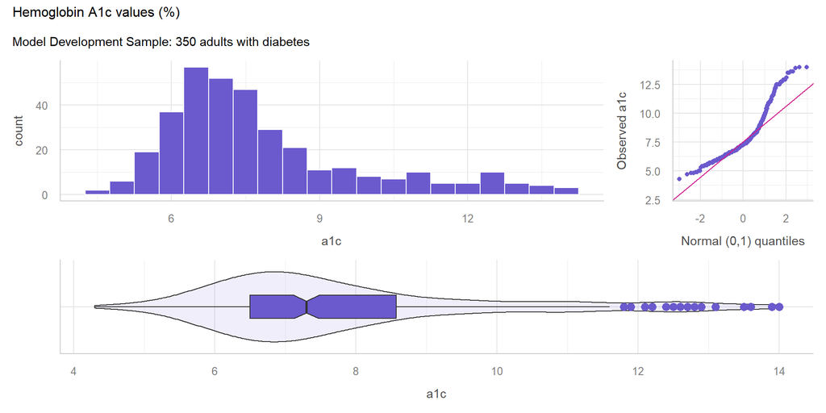

## Box-Cox still suggests inverse?

```r
mod_0 <- lm(a1c ~ a1c_old + age + income,
            data = dm500_i_train)
boxCox(mod_0) ## from car package
```

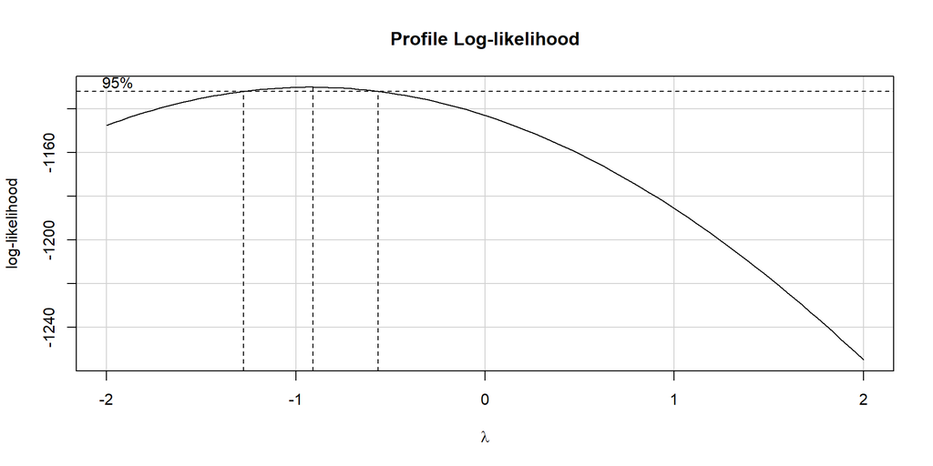

## Scatterplot Matrix

- Rescale inverse transformation with 100/A1c for `transa1c`.

```r
temp <- dm500_i_train |>
  mutate(transa1c = 100/a1c) |>
  select(a1c_old, age, income, transa1c)

ggpairs(temp,
    title = "Scatterplots: Model Development Sample",
    lower = list(combo = wrap("facethist", bins = 10)))
```

## Scatterplot Matrix

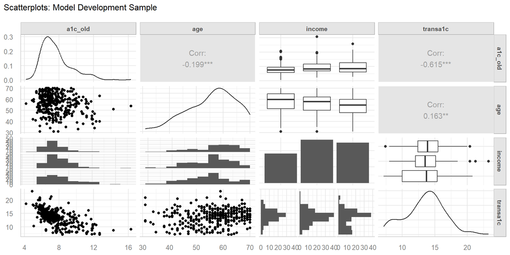

## Fit the three models

- We continue to use the model training sample, and work with the (100/a1c) transformation.

```r
dm500_i_train <- dm500_i_train |> mutate(transa1c = 100/a1c)

fit1 <- lm(transa1c ~ a1c_old, data = dm500_i_train)
fit2 <- lm(transa1c ~ a1c_old + age, data = dm500_i_train)
fit3 <- lm(transa1c ~ a1c_old + age + income,
            data = dm500_i_train)

c(n_obs(fit1), n_obs(fit2), n_obs(fit3))
```

```
[1] 350 350 350
```

## Estimated coefficients (`fit1`)

- 90% confidence intervals, rather than 95% today.
- Notice what `include_info = TRUE` does.

```r
model_parameters(fit1, ci = 0.90, pretty_names = FALSE,
                 include_info = TRUE)
```

```
Parameter   | Coefficient |   SE |         90% CI | t(348) |      p
-------------------------------------------------------------------
(Intercept) |       21.54 | 0.57 | [20.60, 22.48] |  37.94 | < .001
a1c_old     |       -1.05 | 0.07 | [-1.17, -0.93] | -14.56 | < .001

Model: transa1c ~ a1c_old (350 Observations)
Sigma: 2.342 (df = 348)
RMSE : 2.335
R2: 0.379; adjusted R2: 0.377
```

## Making this prettier?

```r
model_parameters(fit1, ci = 0.90, pretty_names = FALSE,
                 include_info = TRUE) |>
  print_md()
```

| Parameter | Coefficient | SE | 90% CI | t(348) | p |
| --- | --- | --- | --- | --- | --- |
| (Intercept) | 21.54 | 0.57 | (20.60, 22.48) | 37.94 | < .001 |
| a1c_old | -1.05 | 0.07 | (-1.17, -0.93) | -14.56 | < .001 |

Model: transa1c ~ a1c_old (350 Observations) Sigma: 2.342 (df = 348) RMSE : 2.335 R2: 0.379; adjusted R2: 0.377

## Can we use bootstrap CIs?

```r
set.seed(431)
model_parameters(fit1, ci = 0.90, pretty_names = FALSE,
                 bootstrap = TRUE, iterations = 1000)
```

```
Parameter   | Coefficient |         90% CI |      p
---------------------------------------------------
(Intercept) |       21.59 | [20.58, 22.70] | < .001
a1c_old     |       -1.05 | [-1.20, -0.93] | < .001
```

Compare to our t-based intervals:

```r
model_parameters(fit1, ci = 0.90)
```

```
Parameter   | Coefficient |   SE |         90% CI | t(348) |      p
-------------------------------------------------------------------
(Intercept) |       21.54 | 0.57 | [20.60, 22.48] |  37.94 | < .001
a1c old     |       -1.05 | 0.07 | [-1.17, -0.93] | -14.56 | < .001
```

- What does `pretty_names = FALSE` do?

## `fit2` parameters

```r
model_parameters(fit2, ci = 0.90, pretty_names = FALSE,
                 include_info = TRUE)
```

```
Parameter   | Coefficient |   SE |         90% CI | t(347) |      p
-------------------------------------------------------------------
(Intercept) |       20.64 | 1.07 | [18.88, 22.40] |  19.30 | < .001
a1c_old     |       -1.04 | 0.07 | [-1.16, -0.91] | -14.07 | < .001
age         |        0.01 | 0.01 | [-0.01,  0.04] |   0.99 | 0.321

Model: transa1c ~ a1c_old + age (350 Observations)
Sigma: 2.342 (df = 347)
RMSE : 2.332
R2: 0.380; adjusted R2: 0.377
```

## `fit3` parameters

```r
model_parameters(fit3, ci = 0.90, pretty_names = FALSE,
                 include_info = TRUE)
```

```
Parameter            | Coefficient |   SE |         90% CI | t(345) |      p
----------------------------------------------------------------------------
(Intercept)          |       20.70 | 1.09 | [18.90, 22.51] |  18.92 | < .001
a1c_old              |       -1.03 | 0.07 | [-1.16, -0.91] | -13.91 | < .001
age                  |        0.01 | 0.01 | [-0.01,  0.04] |   0.88 | 0.381
incomeBetween_30-50K |        0.19 | 0.32 | [-0.34,  0.72] |   0.59 | 0.553
incomeBelow_30K      |       -0.18 | 0.33 | [-0.73,  0.36] |  -0.56 | 0.578

Model: transa1c ~ a1c_old + age + income (350 Observations)
Sigma: 2.343 (df = 345)
RMSE : 2.326
R2: 0.383; adjusted R2: 0.376
```

## `fit1` performance

```r
model_performance(fit1)
```

```
# Indices of model performance

AIC    |   AICc |    BIC |    R2 | R2 (adj.) |  RMSE | Sigma
------------------------------------------------------------
1592.9 | 1593.0 | 1604.5 | 0.379 |     0.377 | 2.335 | 2.342
```

```r
model_performance(fit1, metrics = "common") |>
  print_md(digits = 3)
```

Indices of model performance

| AIC | BIC | R2 | R2 (adj.) | RMSE |
| --- | --- | --- | --- | --- |
| 1592.9 | 1604.5 | 0.379 | 0.377 | 2.335 |

## Compare Fit Quality

- Same results<sup>1</sup> as last week?

```r
compare_performance(fit1, fit2, fit3, rank = TRUE)
```

```
# Comparison of Model Performance Indices

Name | Model |    R2 | R2 (adj.) |  RMSE | Sigma | AIC weights | AICc weights
-----------------------------------------------------------------------------
fit1 |    lm | 0.379 |     0.377 | 2.335 | 2.342 |       0.558 |        0.567
fit2 |    lm | 0.380 |     0.377 | 2.332 | 2.342 |       0.337 |        0.335
fit3 |    lm | 0.383 |     0.376 | 2.326 | 2.343 |       0.105 |        0.097

Name | BIC weights | Performance-Score
--------------------------------------
fit1 |       0.919 |            71.43%
fit2 |       0.081 |            54.14%
fit3 |    5.28e-04 |            28.57%
```

[^1]: `compare_performance()` weights AIC / BIC so higher values mean better fit.

## Performance Comparison

```r
plot(compare_performance(fit1, fit2, fit3))
```

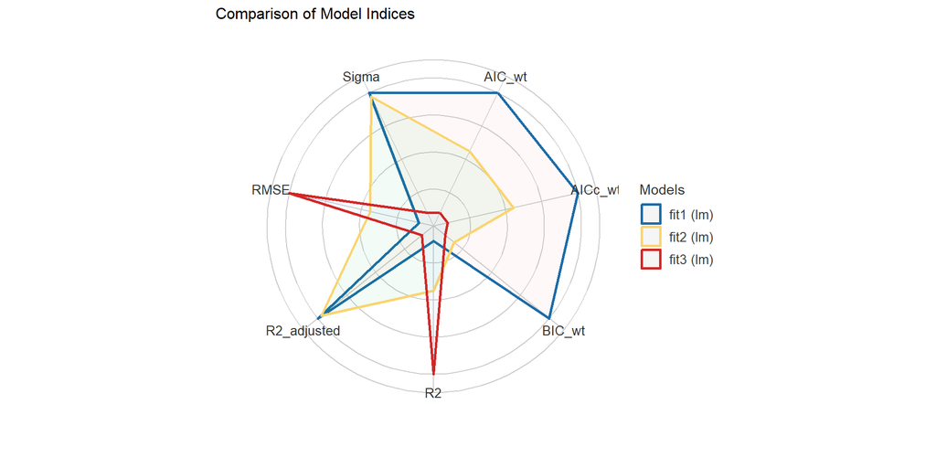

# Assumption Checking (done in the Training Sample)

## Assessing the models with `check_model()`

Three key assumptions we need to think about:

1. Linearity
2. Constant Variance (Homoscedasticity)
3. Normality

How do we assess 1, 2, and 3? Residual plots.

## In the slides, these are too short!

```r
check_model(fit1, detrend = FALSE)
```

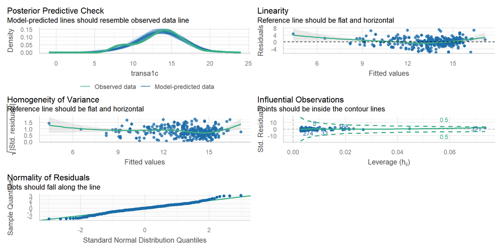

## Fixing the “too short” problem?

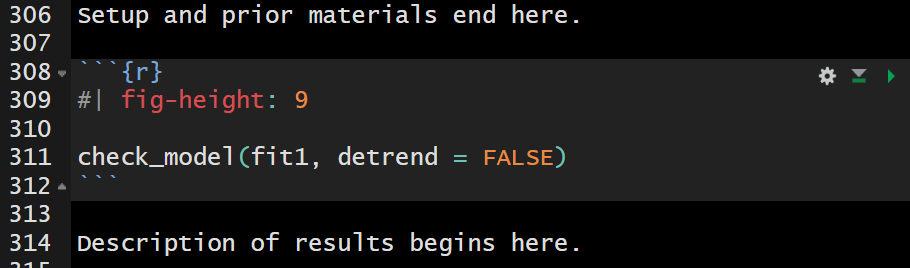

- Note where the blank lines are and where they **are not**.
- Check the result in your HTML!

## `fit1`: Linearity & Homoscedasticity

```r
check_model(fit1, check = c("linearity", "homogeneity"))
```

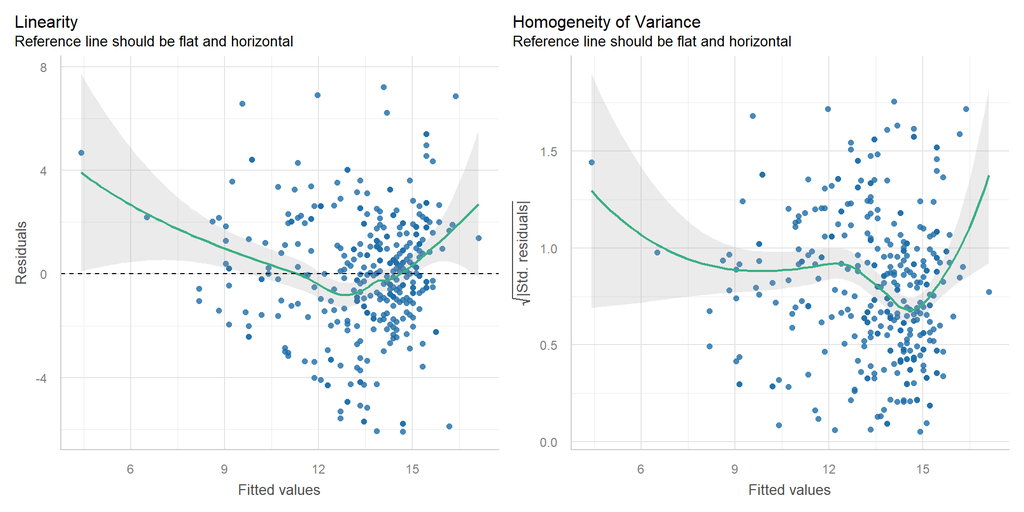

## `fit2`: Linearity & Homoscedasticity

```r
check_model(fit2, check = c("linearity", "homogeneity"))
```

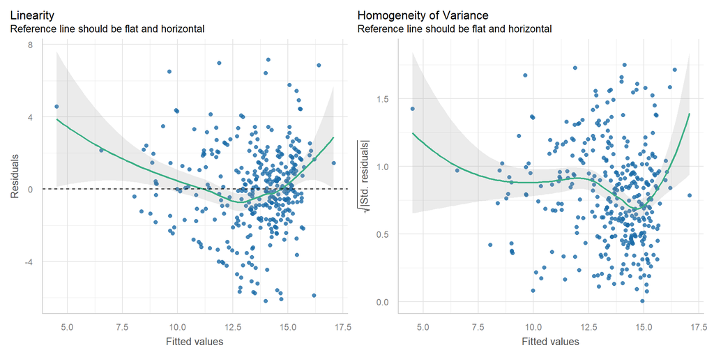

## `fit3`: Linearity & Homoscedasticity

```r
check_model(fit3, check = c("linearity", "homogeneity"))
```

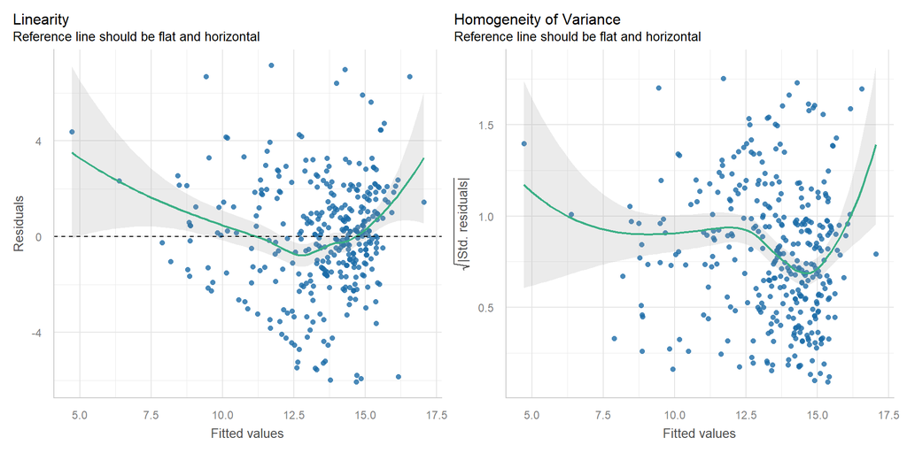

## Influential Observations in `fit1`?

```r
check_model(fit1, check = "outliers")
```

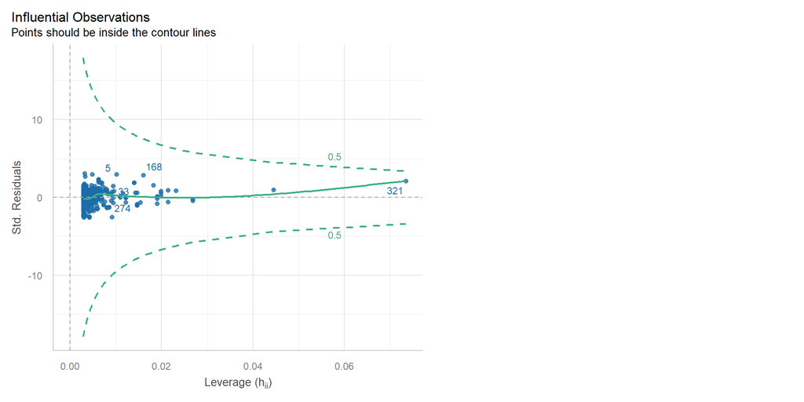

## Looking at row 321?

```r
dm500_i_train |> slice(321) |>
  gt() |> tab_options(table.font.size = 20)
```

| a1c | a1c_old | age | income | subject | transa1c |
| --- | --- | --- | --- | --- | --- |
| 11 | 16.3 | 54 | Between_30-50K | S-002 | 9.090909 |

## `augment` adds fits, residuals, etc.

from the `broom` package…

```r
aug1 <- augment(fit1, data = dm500_i_train)
```

`aug1` includes all variables in `dm500_i_train` and also:

- `transa1c` = 100/`a1c`, transformed outcome `fit1` predicts
- `.fitted` = fitted (predicted) values of 100/`a1c`
- `.resid` = residual (observed - fitted outcome) values; larger residuals (positive or negative) mean poorer fit
- `.std.resid` = standardized residuals (residuals scaled to SD = 1, remember residual mean is already 0)

## What does `augment` give us?

`aug1` also includes:

- `.hat` statistic = measures *leverage* (larger values of `.hat` indicate unusual combinations of predictor values)
- `.cooksd` = Cook’s distance (or Cook’s d), a measure of the subject’s *influence* on the model (larger Cook’s d values indicate that removing the point will materially change the model’s coefficients)
- plus `.sigma` = estimated $\sigma$ if this point is dropped from the model

## `augment` results

```r
aug1 |> gt_preview(top_n = 7, bottom_n = 3)
```

|  | a1c | a1c_old | age | income | subject | transa1c | .fitted | .resid | .hat | .sigma | .cooksd | .std.resid |
| --- | --- | --- | --- | --- | --- | --- | --- | --- | --- | --- | --- | --- |
| 1 | 12.7 | 9.2 | 54 | Below_30K | S-252 | 7.874016 | 11.871279 | -3.9972633 | 0.005071731 | 2.335335 | 7.463620e-03 | -1.7112267 |
| 2 | 8.0 | 8.0 | 62 | Below_30K | S-069 | 12.500000 | 13.132389 | -0.6323890 | 0.002958770 | 2.344977 | 1.085188e-04 | -0.2704384 |
| 3 | 6.5 | 5.6 | 55 | Below_30K | S-275 | 15.384615 | 15.654609 | -0.2699935 | 0.006937258 | 2.345178 | 4.675117e-05 | -0.1156926 |
| 4 | 7.1 | 10.3 | 56 | Higher_than_50K | S-187 | 14.084507 | 10.715262 | 3.3692455 | 0.009411061 | 2.338172 | 9.925863e-03 | 1.4455283 |
| 5 | 4.3 | 4.9 | 59 | Between_30-50K | S-386 | 23.255814 | 16.390256 | 6.8655576 | 0.010158248 | 2.315781 | 4.455437e-02 | 2.9466842 |
| 6 | 7.1 | 8.0 | 39 | Between_30-50K | S-440 | 14.084507 | 13.132389 | 0.9521181 | 0.002958770 | 2.344665 | 2.459902e-04 | 0.4071692 |
| 7 | 8.3 | 7.0 | 61 | Higher_than_50K | S-269 | 12.048193 | 14.183314 | -2.1351212 | 0.003287055 | 2.342412 | 1.375191e-03 | -0.9132258 |
| 8..347 |  |  |  |  |  |  |  |  |  |  |  |  |
| 348 | 11.5 | 11.8 | 43 | Below_30K | S-064 | 8.695652 | 9.138874 | -0.4432219 | 0.019031709 | 2.345100 | 3.542107e-04 | -0.1910884 |
| 349 | 5.4 | 4.2 | 56 | Higher_than_50K | S-078 | 18.518519 | 17.125904 | 1.3926147 | 0.014309832 | 2.344014 | 2.604156e-03 | 0.5989650 |
| 350 | 10.9 | 8.4 | 54 | Below_30K | S-038 | 9.174312 | 12.712019 | -3.5377071 | 0.003359223 | 2.337495 | 3.858839e-03 | -1.5131891 |

## Summarizing our New Measures

for model `fit1`…

```r
aug1 |> select(transa1c, .fitted:.std.resid) |>
  summary()
```

```
    transa1c         .fitted          .resid              .hat
 Min.   : 7.143   Min.   : 4.41   Min.   :-6.08809   Min.   :0.002858
 1st Qu.:11.662   1st Qu.:12.71   1st Qu.:-1.37938   1st Qu.:0.003121
 Median :13.699   Median :13.92   Median : 0.01877   Median :0.004007
 Mean   :13.476   Mean   :13.48   Mean   : 0.00000   Mean   :0.005714
 3rd Qu.:15.385   3rd Qu.:14.71   3rd Qu.: 1.51743   3rd Qu.:0.005842
 Max.   :23.256   Max.   :17.13   Max.   : 7.19837   Max.   :0.073532
     .sigma         .cooksd            .std.resid
 Min.   :2.313   Min.   :1.800e-08   Min.   :-2.6051184
 1st Qu.:2.342   1st Qu.:1.539e-04   1st Qu.:-0.5902304
 Median :2.344   Median :8.454e-04   Median : 0.0080404
 Mean   :2.342   Mean   :3.251e-03   Mean   : 0.0005387
 3rd Qu.:2.345   3rd Qu.:2.870e-03   3rd Qu.: 0.6491588
 Max.   :2.345   Max.   :1.712e-01   Max.   : 3.0786781
```

## `augment` results: row 321

for model `fit1`…

```r
aug1 |> slice(321) |> gt() |> fmt_number(decimals = 2)
```

| a1c | a1c_old | age | income | subject | transa1c | .fitted | .resid | .hat | .sigma | .cooksd | .std.resid |
| --- | --- | --- | --- | --- | --- | --- | --- | --- | --- | --- | --- |
| 11.00 | 16.30 | 54.00 | Between_30-50K | S-002 | 9.09 | 4.41 | 4.68 | 0.07 | 2.33 | 0.17 | 2.08 |

- We’ll want `augment` results for `fit2` and `fit3` soon.

```r
aug2 <- augment(fit2, data = dm500_i_train)
aug3 <- augment(fit3, data = dm500_i_train)
```

## Testing the largest outlier?

```r
car::outlierTest(fit1)
```

```
No Studentized residuals with Bonferroni p < 0.05
Largest |rstudent|:
    rstudent unadjusted p-value Bonferroni p
111 3.116992          0.0019796      0.69286
```

A studentized residual is just another way to standardize the residuals that has some useful properties here.

- No indication that having a maximum absolute value of 3.12 in a sample of 350 studentized residuals is a major concern about the Normality assumption, given the Bonferroni p-value = 0.693.

## Influential Observations in `fit2`?

```r
check_model(fit2, check = "outliers")
```

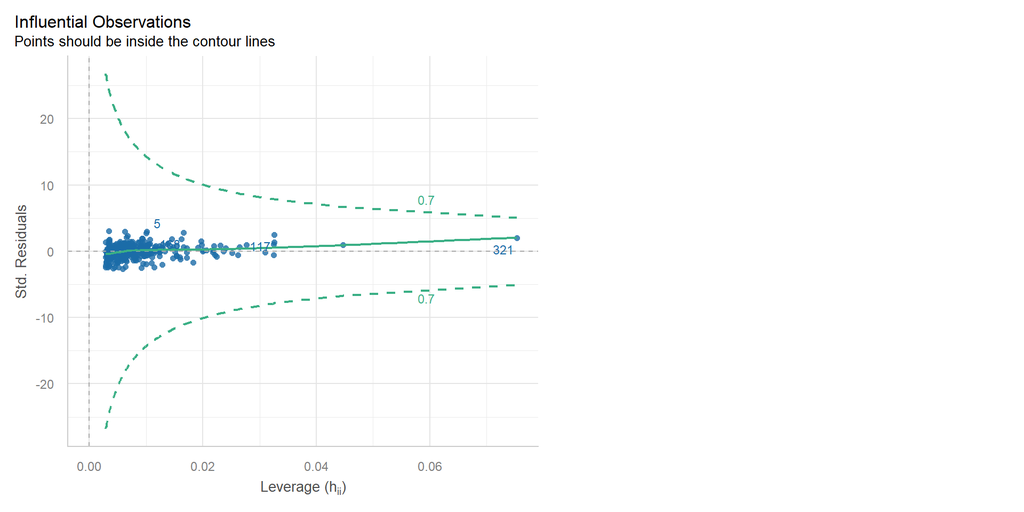

```r
check_model(fit3, check = "outliers")
```

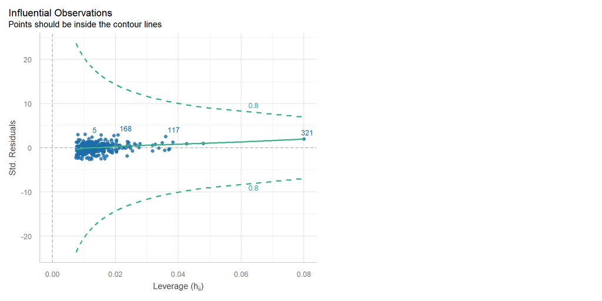

## Testing the largest outlier?

- Model `fit2`

```r
outlierTest(fit2)
```

```
No Studentized residuals with Bonferroni p < 0.05
Largest |rstudent|:
    rstudent unadjusted p-value Bonferroni p
111 3.101016           0.002087      0.73044
```

- Model `fit3`

```r
outlierTest(fit3)
```

```
No Studentized residuals with Bonferroni p < 0.05
Largest |rstudent|:
   rstudent unadjusted p-value Bonferroni p
56 3.108793          0.0020352      0.71232
```

## Normality Check of `fit1` Residuals?

```r
check_model(fit1, check = c("qq", "normality"),
            detrend = FALSE)
```

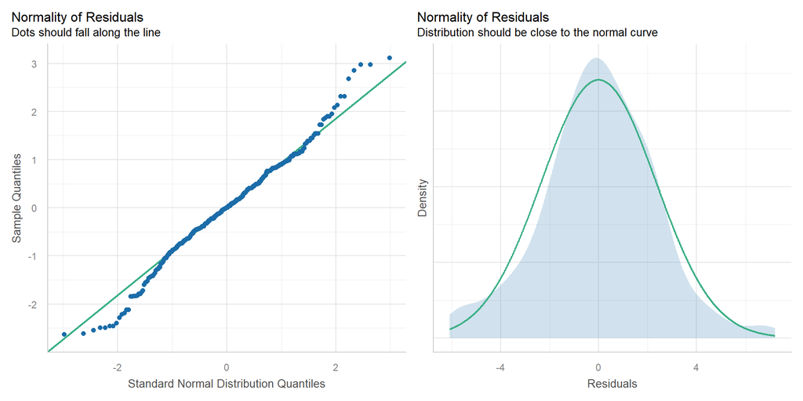

## `fit1`: poorly fit points

```r
which.max(aug1$.std.resid); which.min(aug1$.std.resid)
```

```
[1] 111
```

```
[1] 124
```

```r
slice(aug1, c(111, 124)) |> gt() |>
  fmt_number(columns = c(transa1c:.std.resid), decimals = 3)
```

| a1c | a1c_old | age | income | subject | transa1c | .fitted | .resid | .hat | .sigma | .cooksd | .std.resid |
| --- | --- | --- | --- | --- | --- | --- | --- | --- | --- | --- | --- |
| 4.7 | 7.1 | 59 | Between_30-50K | S-164 | 21.277 | 14.078 | 7.198 | 0.003 | 2.313 | 0.015 | 3.079 |
| 11.6 | 6.5 | 56 | Higher_than_50K | S-488 | 8.621 | 14.709 | −6.088 | 0.004 | 2.322 | 0.014 | −2.605 |

```r
aug1 |> arrange(desc(abs(.std.resid))) |>
  head(3) |> gt() |>
  fmt_number(columns = c(transa1c:.std.resid), n_sigfig = 3)
```

| a1c | a1c_old | age | income | subject | transa1c | .fitted | .resid | .hat | .sigma | .cooksd | .std.resid |
| --- | --- | --- | --- | --- | --- | --- | --- | --- | --- | --- | --- |
| 4.7 | 7.1 | 59 | Between_30-50K | S-164 | 21.3 | 14.1 | 7.20 | 0.00317 | 2.31 | 0.0151 | 3.08 |
| 5.3 | 9.1 | 48 | Below_30K | S-071 | 18.9 | 12.0 | 6.89 | 0.00479 | 2.32 | 0.0209 | 2.95 |
| 4.3 | 4.9 | 59 | Between_30-50K | S-386 | 23.3 | 16.4 | 6.87 | 0.0102 | 2.32 | 0.0446 | 2.95 |

## Normality Check of `fit2` Residuals?

```r
check_model(fit2, check = c("qq", "normality"),
            detrend = FALSE)
```

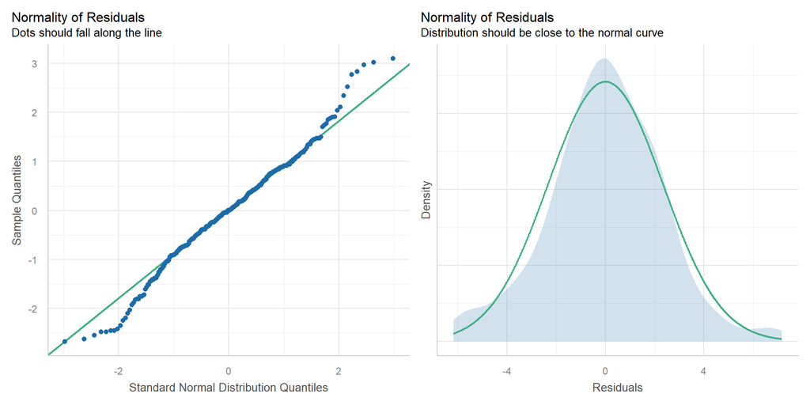

## `fit2`: 8 poorly fit points

```r
aug2 |> arrange(desc(abs(.std.resid))) |>
  head(8) |>
  gt() |>
  fmt_number(columns = c(transa1c:.std.resid), decimals = 3)
```

| a1c | a1c_old | age | income | subject | transa1c | .fitted | .resid | .hat | .sigma | .cooksd | .std.resid |
| --- | --- | --- | --- | --- | --- | --- | --- | --- | --- | --- | --- |
| 4.7 | 7.1 | 59 | Between_30-50K | S-164 | 21.277 | 14.115 | 7.161 | 0.003 | 2.313 | 0.011 | 3.063 |
| 5.3 | 9.1 | 48 | Below_30K | S-071 | 18.868 | 11.887 | 6.981 | 0.006 | 2.315 | 0.019 | 2.990 |
| 4.3 | 4.9 | 59 | Between_30-50K | S-386 | 23.256 | 16.395 | 6.861 | 0.010 | 2.316 | 0.030 | 2.945 |
| 6.2 | 11.4 | 56 | Below_30K | S-341 | 16.129 | 9.616 | 6.513 | 0.017 | 2.319 | 0.044 | 2.804 |
| 4.9 | 7.0 | 43 | Higher_than_50K | S-052 | 20.408 | 13.993 | 6.416 | 0.010 | 2.320 | 0.026 | 2.753 |
| 12.8 | 7.3 | 65 | Below_30K | S-214 | 7.812 | 13.993 | −6.180 | 0.006 | 2.321 | 0.014 | −2.647 |
| 11.6 | 6.5 | 56 | Higher_than_50K | S-488 | 8.621 | 14.695 | −6.074 | 0.004 | 2.322 | 0.009 | −2.599 |
| 9.7 | 5.1 | 58 | Higher_than_50K | S-368 | 10.309 | 16.174 | −5.864 | 0.009 | 2.324 | 0.019 | −2.516 |

## Normality Check of `fit3` Residuals?

```r
check_model(fit3, check = c("qq", "normality"),
            detrend = FALSE)
```

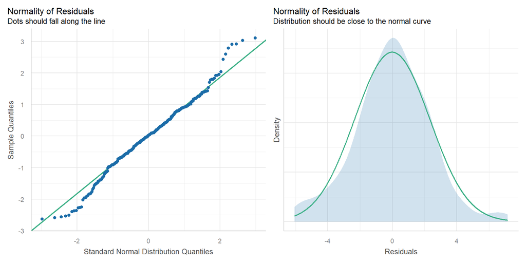

## `fit3`: 8 poorly fit points

```r
aug3 |> arrange(desc(abs(.std.resid))) |>
  head(8) |>
  gt() |>
  fmt_number(columns = c(transa1c:.std.resid), decimals = 3)
```

| a1c | a1c_old | age | income | subject | transa1c | .fitted | .resid | .hat | .sigma | .cooksd | .std.resid |
| --- | --- | --- | --- | --- | --- | --- | --- | --- | --- | --- | --- |
| 5.3 | 9.1 | 48 | Below_30K | S-071 | 18.868 | 11.711 | 7.157 | 0.010 | 2.314 | 0.020 | 3.070 |
| 4.7 | 7.1 | 59 | Between_30-50K | S-164 | 21.277 | 14.292 | 6.984 | 0.008 | 2.316 | 0.015 | 2.993 |
| 6.2 | 11.4 | 56 | Below_30K | S-341 | 16.129 | 9.432 | 6.697 | 0.021 | 2.318 | 0.035 | 2.888 |
| 4.3 | 4.9 | 59 | Between_30-50K | S-386 | 23.256 | 16.568 | 6.688 | 0.015 | 2.318 | 0.026 | 2.876 |
| 4.9 | 7.0 | 43 | Higher_than_50K | S-052 | 20.408 | 14.004 | 6.405 | 0.019 | 2.320 | 0.030 | 2.760 |
| 11.6 | 6.5 | 56 | Higher_than_50K | S-488 | 8.621 | 14.685 | −6.064 | 0.012 | 2.323 | 0.016 | −2.603 |
| 4.8 | 5.8 | 31 | Below_30K | S-464 | 20.833 | 14.910 | 5.923 | 0.036 | 2.324 | 0.050 | 2.575 |
| 12.8 | 7.3 | 65 | Below_30K | S-214 | 7.812 | 13.787 | −5.974 | 0.012 | 2.324 | 0.017 | −2.566 |

# Collinearity

## Checking for Collinearity

Collinearity refers to correlations between predictors.

- Strong correlations between predictors can inflate the variance of our estimates, and also make it hard to distinguish effects attributable to correlated predictors.
- When we have multiple predictors (as in `fit2` and `fit3`) it is worth quantifying the extent to which our variances are inflated by collinearity.
- We can estimate the effect of collinearity directly through the `vif()` function in the `car` package, or …

## `fit2`: Collinearity Check

```r
check_collinearity(fit2)
```

```
# Check for Multicollinearity

Low Correlation

    Term  VIF   VIF 95% CI adj. VIF Tolerance Tolerance 95% CI
 a1c_old 1.04 [1.00, 1.62]     1.02      0.96     [0.62, 1.00]
     age 1.04 [1.00, 1.62]     1.02      0.96     [0.62, 1.00]
```

- (generalized) variance inflation factors above 5 are worthy of our special attention

## Model `fit2` Check for Collinearity

```r
check_model(fit2, check = "vif")
```

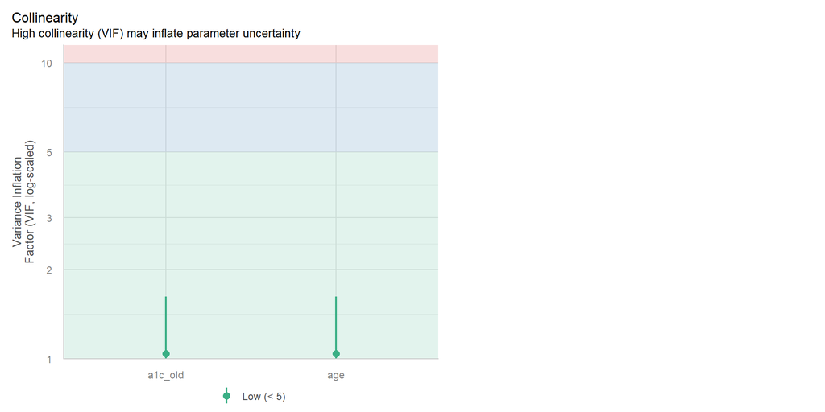

## `fit3`: Collinearity Check

```r
check_collinearity(fit3)
```

```
# Check for Multicollinearity

Low Correlation

    Term  VIF   VIF 95% CI adj. VIF Tolerance Tolerance 95% CI
 a1c_old 1.06 [1.01, 1.40]     1.03      0.94     [0.71, 0.99]
     age 1.06 [1.01, 1.40]     1.03      0.94     [0.71, 0.99]
  income 1.05 [1.00, 1.52]     1.01      0.96     [0.66, 1.00]
```

- If there’s no problem with collinearity in `fit3`, can there be a problem with collinearity in `fit2`, which contains a subset of the same predictors?

## Model `fit3` Check for Collinearity

```r
check_model(fit3, check = "vif")
```

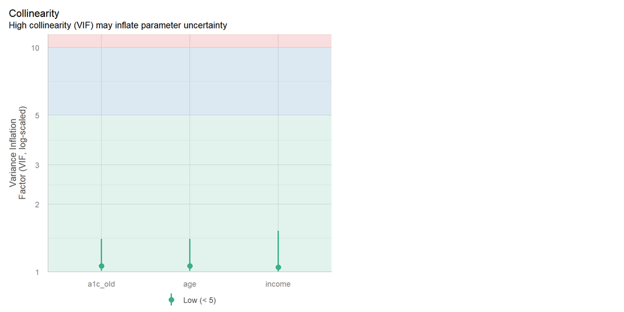

# Posterior Predictive Checks

## Posterior Predictive Check: `fit1`

```r
check_model(fit1, check = "pp_check")
```

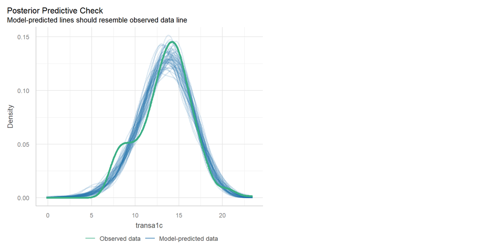

## `fit1`: Observed vs. Predicted

```r
ggplot(aug1, aes(x = .fitted, y = transa1c)) +
  geom_point() +
  geom_abline(slope = 1, intercept = 0,
              lwd = 2, lty = "dashed", col = "magenta")
```

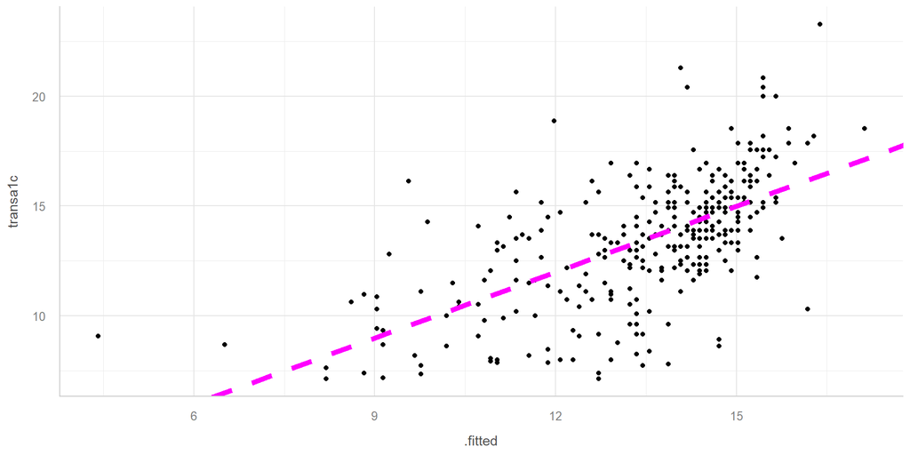

## `fit1`: Observed and Predicted

```r
aug1 |> reframe(lovedist(transa1c))
```

```
# A tibble: 1 × 10
      n  miss  mean    sd   med   mad   min   q25   q75   max
  <int> <int> <dbl> <dbl> <dbl> <dbl> <dbl> <dbl> <dbl> <dbl>
1   350     0  13.5  2.97  13.7  2.50  7.14  11.7  15.4  23.3
```

```r
aug1 |> reframe(lovedist(.fitted))
```

```
# A tibble: 1 × 10
      n  miss  mean    sd   med   mad   min   q25   q75   max
  <int> <int> <dbl> <dbl> <dbl> <dbl> <dbl> <dbl> <dbl> <dbl>
1   350     0  13.5  1.83  13.9  1.48  4.41  12.7  14.7  17.1
```

```r
cor(aug1$transa1c, aug1$.fitted); cor(aug1$transa1c, aug1$.fitted)^2
```

```
[1] 0.6153499
```

```
[1] 0.3786555
```

```r
r2(fit1)
```

```
# R2 for Linear Regression
       R2: 0.379
  adj. R2: 0.377
```

## `fit1`: Predictions and Observed

```r
p1 <- ggplot(aug1, aes(x = .fitted, y = "")) +
  geom_violin() +
  geom_boxplot(fill = "royalblue", alpha = 0.5, width = 0.3) +
  xlim(0, 25) +
  stat_summary(fun = "mean", col = "red") +
  labs(title = "Predicted 100/A1c values (model fit1)", y = "")

p2 <- ggplot(aug1, aes(x = transa1c, y = "")) +
  geom_violin() +
  geom_boxplot(fill = "mistyrose", alpha = 0.5, width = 0.3) +
  xlim(0, 25) +
  stat_summary(fun = "mean", col = "red") +
  labs(title = "Observed 100/A1c values", y = "")

p1 / p2
```

[output not shown]

## `fit1`: Predictions and Observed

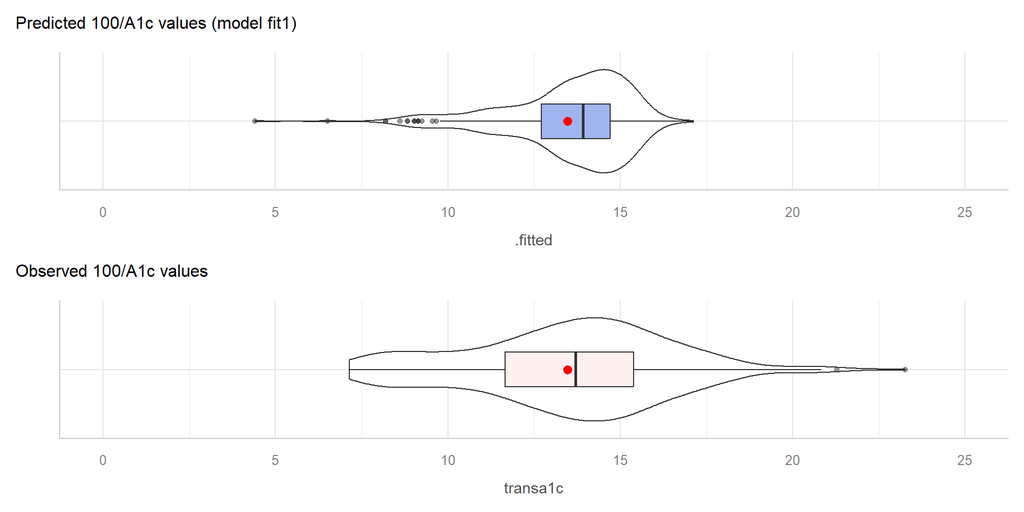

## Posterior Predictive Check: `fit2`

```r
check_model(fit2, check = "pp_check")
```

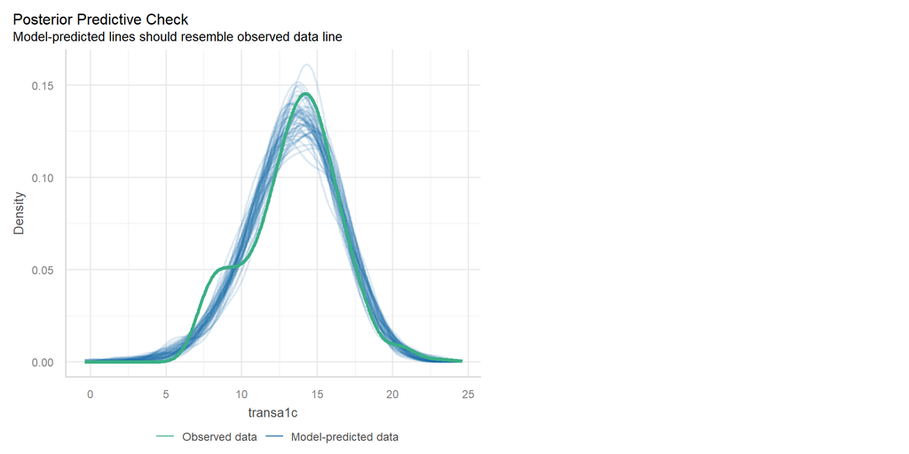

## `fit2`: Predictions and Observed

```r
p1 <- ggplot(aug2, aes(x = .fitted, y = "")) +
  geom_violin() +
  geom_boxplot(fill = "royalblue", alpha = 0.5, width = 0.3) +
  xlim(0, 25) +
  stat_summary(fun = "mean", col = "red") +
  labs(title = "Predicted 100/A1c values (model fit2)", y = "")

p2 <- ggplot(aug2, aes(x = transa1c, y = "")) +
  geom_violin() +
  geom_boxplot(fill = "mistyrose", alpha = 0.5, width = 0.3) +
  xlim(0, 25) +
  stat_summary(fun = "mean", col = "red") +
  labs(title = "Observed 100/A1c values", y = "")

p1 / p2
```

## `fit2`: Predictions and Observed

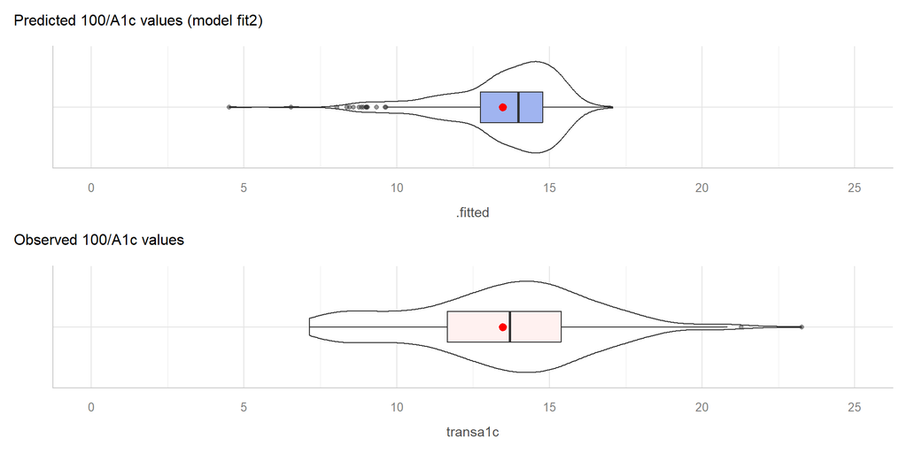

## `fit2`: Observed and Predicted

```r
aug2 |> reframe(lovedist(transa1c))
```

```
# A tibble: 1 × 10
      n  miss  mean    sd   med   mad   min   q25   q75   max
  <int> <int> <dbl> <dbl> <dbl> <dbl> <dbl> <dbl> <dbl> <dbl>
1   350     0  13.5  2.97  13.7  2.50  7.14  11.7  15.4  23.3
```

```r
aug2 |> reframe(lovedist(.fitted))
```

```
# A tibble: 1 × 10
      n  miss  mean    sd   med   mad   min   q25   q75   max
  <int> <int> <dbl> <dbl> <dbl> <dbl> <dbl> <dbl> <dbl> <dbl>
1   350     0  13.5  1.83  14.0  1.46  4.51  12.7  14.8  17.1
```

```r
cor(aug2$transa1c, aug2$.fitted); cor(aug2$transa1c, aug2$.fitted)^2
```

```
[1] 0.6167804
```

```
[1] 0.380418
```

```r
r2(fit2)
```

```
# R2 for Linear Regression
       R2: 0.380
  adj. R2: 0.377
```

## Posterior Predictive Check: `fit3`

```r
check_model(fit3, check = "pp_check")
```

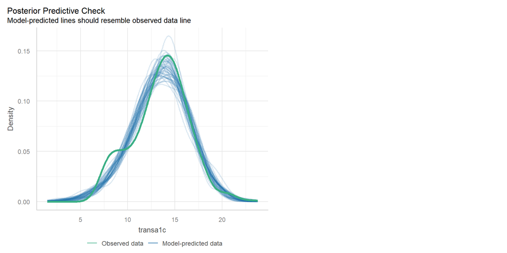

## `fit3`: Predictions and Observed

```r
p1 <- ggplot(aug3, aes(x = .fitted, y = "")) +
  geom_violin() +
  geom_boxplot(fill = "royalblue", alpha = 0.5, width = 0.3) +
  xlim(0, 25) +
  stat_summary(fun = "mean", col = "red") +
  labs(title = "Predicted 100/A1c values (model fit3)", y = "")

p2 <- ggplot(aug1, aes(x = transa1c, y = "")) +
  geom_violin() +
  geom_boxplot(fill = "mistyrose", alpha = 0.5, width = 0.3) +
  xlim(0, 25) +
  stat_summary(fun = "mean", col = "red") +
  labs(title = "Observed 100/A1c values", y = "")

p1 / p2
```

## `fit3`: Predictions and Observed

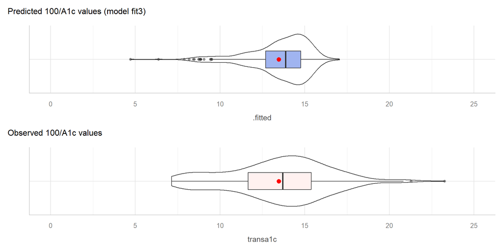

## `fit3`: Observed and Predicted

```r
aug3 |> reframe(lovedist(transa1c))
```

```
# A tibble: 1 × 10
      n  miss  mean    sd   med   mad   min   q25   q75   max
  <int> <int> <dbl> <dbl> <dbl> <dbl> <dbl> <dbl> <dbl> <dbl>
1   350     0  13.5  2.97  13.7  2.50  7.14  11.7  15.4  23.3
```

```r
aug3 |> reframe(lovedist(.fitted))
```

```
# A tibble: 1 × 10
      n  miss  mean    sd   med   mad   min   q25   q75   max
  <int> <int> <dbl> <dbl> <dbl> <dbl> <dbl> <dbl> <dbl> <dbl>
1   350     0  13.5  1.84  13.9  1.47  4.71  12.7  14.8  17.1
```

```r
cor(aug3$transa1c, aug3$.fitted); cor(aug3$transa1c, aug3$.fitted)^2
```

```
[1] 0.6191479
```

```
[1] 0.3833441
```

```r
r2(fit3)
```

```
# R2 for Linear Regression
       R2: 0.383
  adj. R2: 0.376
```

# Extending to the Test Sample

## Making Predictions: Test Sample

- Create transformed outcome in test sample.
- For OLS fits, apply `augment()` to new data = test sample.

```r
dm500_i_test <- dm500_i_test |> mutate(transa1c = 100/a1c)

aug1_test <- augment(fit1, newdata = dm500_i_test) |>
  mutate(mod = "fit1")
aug2_test <- augment(fit2, newdata = dm500_i_test) |>
  mutate(mod = "fit2")
aug3_test <- augment(fit3, newdata = dm500_i_test) |>
  mutate(mod = "fit3")
```

Results on next slide…

## `augment` for each model

```r
aug1_test |> head(2) |> gt()
```

| a1c | a1c_old | age | income | subject | transa1c | .fitted | .resid | mod |
| --- | --- | --- | --- | --- | --- | --- | --- | --- |
| 6.3 | 11.4 | 62 | Higher_than_50K | S-001 | 15.87302 | 9.559244 | 6.31377179 | fit1 |
| 6.5 | 5.8 | 53 | Below_30K | S-004 | 15.38462 | 15.444424 | -0.05980853 | fit1 |

```r
aug2_test |> head(2) |> gt()
```

| a1c | a1c_old | age | income | subject | transa1c | .fitted | .resid | mod |
| --- | --- | --- | --- | --- | --- | --- | --- | --- |
| 6.3 | 11.4 | 62 | Higher_than_50K | S-001 | 15.87302 | 9.701117 | 6.171898626 | fit2 |
| 6.5 | 5.8 | 53 | Below_30K | S-004 | 15.38462 | 15.377594 | 0.007020891 | fit2 |

```r
aug3_test |> head(2) |> gt()
```

| a1c | a1c_old | age | income | subject | transa1c | .fitted | .resid | mod |
| --- | --- | --- | --- | --- | --- | --- | --- | --- |
| 6.3 | 11.4 | 62 | Higher_than_50K | S-001 | 15.87302 | 9.691255 | 6.1817606 | fit3 |
| 6.5 | 5.8 | 53 | Below_30K | S-004 | 15.38462 | 15.187314 | 0.1973018 | fit3 |

## Combine Augmented Results

```r
temp12 <- bind_rows(aug1_test, aug2_test)
test_res <- bind_rows(temp12, aug3_test) |>
  relocate(subject, mod, a1c, everything()) |>
  arrange(subject, mod)

test_res |> head() |> gt() |> tab_options(table.font.size = 20)
```

| subject | mod | a1c | a1c_old | age | income | transa1c | .fitted | .resid |
| --- | --- | --- | --- | --- | --- | --- | --- | --- |
| S-001 | fit1 | 6.3 | 11.4 | 62 | Higher_than_50K | 15.87302 | 9.559244 | 6.313771788 |
| S-001 | fit2 | 6.3 | 11.4 | 62 | Higher_than_50K | 15.87302 | 9.701117 | 6.171898626 |
| S-001 | fit3 | 6.3 | 11.4 | 62 | Higher_than_50K | 15.87302 | 9.691255 | 6.181760567 |
| S-004 | fit1 | 6.5 | 5.8 | 53 | Below_30K | 15.38462 | 15.444424 | -0.059808527 |
| S-004 | fit2 | 6.5 | 5.8 | 53 | Below_30K | 15.38462 | 15.377594 | 0.007020891 |
| S-004 | fit3 | 6.5 | 5.8 | 53 | Below_30K | 15.38462 | 15.187314 | 0.197301765 |

## Calculating Prediction Errors

For each of our (OLS) models, we have:

- `a1c`, the outcome we actually care about
- `transa1c` = 100/`a1c`, the transformed outcome
- `.fitted`, a predicted `transa1c` from the model

What we want is

- `a1c_pred`, the predicted `a1c` using this model, and
- `a1c_error`, the error made in predicting `a1c`

## Back-Transformation

Each `.fitted` value is a prediction of 100/`a1c`.

$$\frac{100}{a1c} = \mbox{.fitted}, \mbox{ so } \frac{1}{a1c} = \frac{\mbox{.fitted}}{100}, \mbox{ and so}\\
a1c = \frac{100}{\mbox{.fitted}}$$

To get `a1c_pred` we need to back-transform our `.fitted` values, with 100/`.fitted`, it seems.

## Adding predicted A1c and error

- We add `a1c_pred`, the predicted `a1c` using this model, and
- `a1c_error` = error for this model in predicting `a1c`

```r
test_res <- test_res |>
  mutate(a1c_pred = 100/.fitted,
         a1c_error = a1c - a1c_pred)

test_res |> head(4) |> gt()
```

| subject | mod | a1c | a1c_old | age | income | transa1c | .fitted | .resid | a1c_pred | a1c_error |
| --- | --- | --- | --- | --- | --- | --- | --- | --- | --- | --- |
| S-001 | fit1 | 6.3 | 11.4 | 62 | Higher_than_50K | 15.87302 | 9.559244 | 6.31377179 | 10.461078 | -4.16107821 |
| S-001 | fit2 | 6.3 | 11.4 | 62 | Higher_than_50K | 15.87302 | 9.701117 | 6.17189863 | 10.308091 | -4.00809106 |
| S-001 | fit3 | 6.3 | 11.4 | 62 | Higher_than_50K | 15.87302 | 9.691255 | 6.18176057 | 10.318581 | -4.01858070 |
| S-004 | fit1 | 6.5 | 5.8 | 53 | Below_30K | 15.38462 | 15.444424 | -0.05980853 | 6.474829 | 0.02517125 |

## Summarize Errors for Each Fit

We’ll look at four summary measures in 431…

1. MAPE = mean absolute prediction error
2. Max_APE = maximum absolute prediction error
3. RMSPE = square root of mean squared prediction error
4. Validated $R^2$ = squared correlation of predictions and outcome in the new data

Measures 1-3 are all in the same units as `a1c`, our outcome.

## Building our Four Summaries

The `test_res` tibble contains, for each model,

- `a1c`, the actual outcome value
- `a1c_pred`, the predicted outcome value
- `a1c_error` = `a1c` - `a1c_pred` = prediction error

```r
test_summary <- test_res |>
  group_by(mod) |>
  summarize(MAPE = mean(abs(a1c_error)),
            Max_APE = max(abs(a1c_error)),
            RMSE = sqrt(mean(a1c_error^2)),
            R2_val = cor(a1c, a1c_pred)^2)
```

## Table for Test-Sample Prediction

```r
test_summary |>
  gt() |>
  fmt_number(decimals = 4) |>
  tab_options(table.font.size = 24)
```

| mod | MAPE | Max_APE | RMSE | R2_val |
| --- | --- | --- | --- | --- |
| fit1 | 1.1033 | 5.7532 | 1.6080 | 0.4608 |
| fit2 | 1.0958 | 5.5978 | 1.5911 | 0.4699 |
| fit3 | 1.0959 | 5.8548 | 1.5965 | 0.4685 |

- Which model is best, by these metrics?
- `fit2` has smallest MAPE, Max_APE, RMSPE, and largest validated $R^2$

## Putting this all together

- `fit1` includes `a1c_old`, `fit2` adds `age`, `fit3` adds income
- Similar model assumption issues (hard-to-ignore problem with linearity, maybe non-constant variance)
- **training** sample: `fit3` performed best on $R^2$ and RMSE, `fit1` was best on adjusted $R^2$, AIC, BIC and $\sigma$.
- **test** sample: `fit2` performed best on MAPE, Max(APE), RMSPE and validated $R^2$.
- Only modest differences between models on most metrics.

# I decided to choose Model `fit2`

## Complete Case Analysis

- **Project B Study 2**: Report the model building process, displaying conclusions from training sample (transformation decisions, fitted parameters with CIs and interpretations, comparison of performance metrics, checks of model assumptions) and from test sample (comparison of predictive error)
- Of course, here we did some imputation, so we’d need to do this all over again with complete cases to get these results.

## Simple Imputation

- **Project B Study 2**: Report the model building process, displaying conclusions from training sample (transformation decisions, fitted parameters with CIs and interpretations, comparison of performance metrics, checks of model assumptions) and from test sample (comparison of predictive error)
- Sometimes, we do some of the steps above without reporting them to the public, of course. But that’s not the goal here.

## Model `fit2` using Single Imputation

Estimated using a single imputation in training sample.

```r
model_parameters(fit2, ci = 0.90,
                 pretty_names = FALSE,
                 include_info = TRUE)
```

```
Parameter   | Coefficient |   SE |         90% CI | t(347) |      p
-------------------------------------------------------------------
(Intercept) |       20.64 | 1.07 | [18.88, 22.40] |  19.30 | < .001
a1c_old     |       -1.04 | 0.07 | [-1.16, -0.91] | -14.07 | < .001
age         |        0.01 | 0.01 | [-0.01,  0.04] |   0.99 | 0.321

Model: transa1c ~ a1c_old + age (350 Observations)
Sigma: 2.342 (df = 347)
RMSE : 2.332
R2: 0.380; adjusted R2: 0.377
```

## Incorporating Multiple Imputations

- **Same as Project B Study 2**: Report the model building process, displaying conclusions from training sample (transformation decisions, fitted parameters with CIs and interpretations, comparison of performance metrics, checks of model assumptions) and from test sample (comparison of predictive error)
- **New** Then **add** information on fitted parameters across the whole data set (not split into training and testing) after multiple (in this case, 10) imputations.

## Using Ten Imputations

`dm500_tenimps` contained `mice` results across 10 imputations, then we used the 4th in our work. Let’s build a new set of results across the model we’ve settled on, with a fresh set of 10 imputations.

- The original data (with missing values) are in `dm500` - we need only to add our transformed outcome, 100/`a1c`.

```r
dm500 <- dm500 |> mutate(transa1c = 100/a1c)

imp2_fit <- dm500 |>
  mice(m = 10, seed = 431, print = FALSE) |>
  with(lm(transa1c ~ a1c_old + age)) |>
  pool()
```

## Estimates across 10 imputations

```r
model_parameters(imp2_fit, ci = 0.90,
                 pretty_names = FALSE)
```

```
# Fixed Effects

Parameter   | Coefficient |   SE |         90% CI |      t |     df |      p
----------------------------------------------------------------------------
(Intercept) |       19.93 | 0.85 | [18.53, 21.33] |  23.49 | 485.52 | < .001
a1c_old     |       -1.00 | 0.06 | [-1.10, -0.90] | -16.77 | 465.43 | < .001
age         |        0.02 | 0.01 | [ 0.00,  0.04] |   1.79 | 482.67 | 0.075
```

```r
pool.r.squared(imp2_fit)
```

```
          est     lo 95     hi 95        fmi
R^2 0.3842468 0.3143945 0.4525868 0.06619506
```

```r
pool.r.squared(imp2_fit, adjusted = TRUE)
```

```
              est     lo 95     hi 95        fmi
adj R^2 0.3817684 0.3118849 0.4502088 0.06660368
```

# Bayesian model fits instead?

## Refit with Bayesian models?

What must we change to use Bayesian (`stan_glm`) fits?

1. Must create transformed outcome in data prior to fitting with `rstanarm()`.
2. Results are a bit different for `model_parameters()`
3. Results are a bit different for `model_performance()`
4. No real change for `check_model()`
5. No `augment()` function for `rstanarm()` fits.

## Refit with Bayesian models?

- Single imputation, default weakly informative priors

```r
set.seed(20251111)

fit1B <- stan_glm(transa1c ~ a1c_old,
                  data = dm500_i_train, refresh = 0)
fit2B <- stan_glm(transa1c ~ a1c_old + age,
                  data = dm500_i_train, refresh = 0)
fit3B <- stan_glm(transa1c ~ a1c_old + age + income,
            data = dm500_i_train, refresh = 0)
```

- By default, `stan_glm()` performs 4000 simulations from the joint distribution of parameters.

## Estimating `fit1B` Coefficients?

```r
model_parameters(fit1B, ci = 0.90, pretty_names = FALSE, include_info = TRUE)
```

```
Parameter   | Median |         90% CI |   pd |  Rhat |  ESS |                  Prior
------------------------------------------------------------------------------------
(Intercept) |  21.54 | [20.60, 22.46] | 100% | 1.000 | 4048 | Normal (13.48 +- 7.42)
a1c_old     |  -1.05 | [-1.17, -0.93] | 100% | 1.000 | 3917 |  Normal (0.00 +- 4.27)

Model: transa1c ~ a1c_old (350 Observations)
RMSE : 2.335
: 0.378
```

- `: 0.378` indicates “Bayesian” $R^2$ value
- `pd` = [probability of direction](https://easystats.github.io/bayestestR/reference/p_direction.html), an index of effect existence, representing the certainty with which an effect goes in a particular direction.
- We want `Rhat` < 1.05 and `ESS` > 100.

## `fit2B` Coefficients?

```r
model_parameters(fit2B, ci = 0.90, pretty_names = FALSE) |>
  gt()
```

| Parameter | Median | CI | CI_low | CI_high | pd | Rhat | ESS | Prior_Distribution | Prior_Location | Prior_Scale |
| --- | --- | --- | --- | --- | --- | --- | --- | --- | --- | --- |
| (Intercept) | 20.62084500 | 0.9 | 18.884286939 | 22.43192391 | 1.00000 | 1.000513 | 4032.409 | normal | 13.47619 | 7.4166884 |
| a1c_old | -1.03788107 | 0.9 | -1.156468570 | -0.91340801 | 1.00000 | 1.001463 | 4254.938 | normal | 0.00000 | 4.2696233 |
| age | 0.01459798 | 0.9 | -0.009797824 | 0.03770488 | 0.84625 | 1.000090 | 4756.746 | normal | 0.00000 | 0.8252597 |

- [Rhat and ESS](https://mc-stan.org/rstan/reference/Rhat.html) are diagnostic metrics.
  - If Rhat < 1.05, model convergence is probably OK.
  - If ESS > 100, then estimates are usually reliable.

## `fit3B` Coefficients?

```r
model_parameters(fit3B, ci = 0.90,
                 pretty_names = FALSE) |>
  gt()
```

| Parameter | Median | CI | CI_low | CI_high | pd | Rhat | ESS | Prior_Distribution | Prior_Location | Prior_Scale |
| --- | --- | --- | --- | --- | --- | --- | --- | --- | --- | --- |
| (Intercept) | 20.7072038 | 0.9 | 18.87443659 | 22.4977987 | 1.00000 | 1.0007519 | 3723.033 | normal | 13.47619 | 7.4166884 |
| a1c_old | -1.0334197 | 0.9 | -1.15591666 | -0.9076764 | 1.00000 | 1.0003656 | 3962.910 | normal | 0.00000 | 4.2696233 |
| age | 0.0123540 | 0.9 | -0.01088992 | 0.0368757 | 0.81275 | 1.0007125 | 4312.329 | normal | 0.00000 | 0.8252597 |
| incomeBetween_30-50K | 0.1921164 | 0.9 | -0.34195993 | 0.7207961 | 0.73575 | 0.9992967 | 2880.438 | normal | 0.00000 | 15.2362290 |
| incomeBelow_30K | -0.1734018 | 0.9 | -0.73343326 | 0.3738690 | 0.70850 | 0.9999700 | 2677.998 | normal | 0.00000 | 15.4564766 |

## Model Performance with `fit1B`?

```r
model_performance(fit1B)
```

```
# Indices of model performance

ELPD     | ELPD_SE |  LOOIC | LOOIC_SE |   WAIC |    R2 | R2 (adj.) |  RMSE | Sigma
-----------------------------------------------------------------------------------
-796.711 |  15.056 | 1593.4 |   30.112 | 1593.4 | 0.378 |     0.373 | 2.335 | 2.347
```

- `R2` = “unadjusted” Bayesian $R^2$ (see [r2_bayes](https://easystats.github.io/performance/reference/r2_bayes.html) for details)
- `R2_adjusted` = leave-one-out cross-validation (LOO) adjusted $R^2$, which is conceptually closer to our OLS adjusted $R^2$ than some other options.
- `RMSE` = root mean squared error, so lower values mean better fit.

## Bayesian Model Performance

```r
model_performance(fit2B)
```

```
# Indices of model performance

ELPD     | ELPD_SE |  LOOIC | LOOIC_SE |   WAIC |    R2 | R2 (adj.) |  RMSE | Sigma
-----------------------------------------------------------------------------------
-797.335 |  15.158 | 1594.7 |   30.316 | 1594.7 | 0.380 |     0.372 | 2.332 | 2.348
```

- `Sigma` = residual standard deviation (95% of in-sample predictions should be within $\pm 2 \sigma$)
- `WAIC` = Widely Applicable Information Criterion. Lower WAIC values mean better fit.

## Bayesian Model Performance

```r
model_performance(fit3B)
```

```
# Indices of model performance

ELPD     | ELPD_SE |  LOOIC | LOOIC_SE |   WAIC |    R2 | R2 (adj.) |  RMSE | Sigma
-----------------------------------------------------------------------------------
-798.461 |  15.113 | 1596.9 |   30.226 | 1596.9 | 0.382 |     0.368 | 2.326 | 2.349
```

- `ELPD` = expected log predictive density. Larger ELPD means better fit.
- `LOOIC` = leave-one-out cross-validation (LOO) information criterion. Lower LOOIC means better fit.
- `LOOIC_SE` = standard error of LOOIC

[Performance of Bayesian Models](https://easystats.github.io/performance/reference/model_performance.stanreg.html) describes more options.

## Performance in Training Sample?

```r
compare_performance(fit1B, fit2B, fit3B, rank = TRUE) |>
  gt() |> fmt_number(decimals = 3) |>
  tab_options(table.font.size = 20)
```

| Name | Model | R2 | R2_adjusted | RMSE | Sigma | WAIC_wt | LOOIC_wt | Performance_Score |
| --- | --- | --- | --- | --- | --- | --- | --- | --- |
| fit1B | stanreg | 0.378 | 0.373 | 2.335 | 2.347 | 0.583 | 1.000 | 0.667 |
| fit2B | stanreg | 0.380 | 0.372 | 2.332 | 2.348 | 0.314 | 0.000 | 0.409 |
| fit3B | stanreg | 0.382 | 0.368 | 2.326 | 2.349 | 0.102 | 0.000 | 0.333 |

## Bayes Performance Indicators?

```r
plot(compare_performance(fit1B, fit2B, fit3B,
          metrics = c("WAIC", "R2", "RMSE")))
```

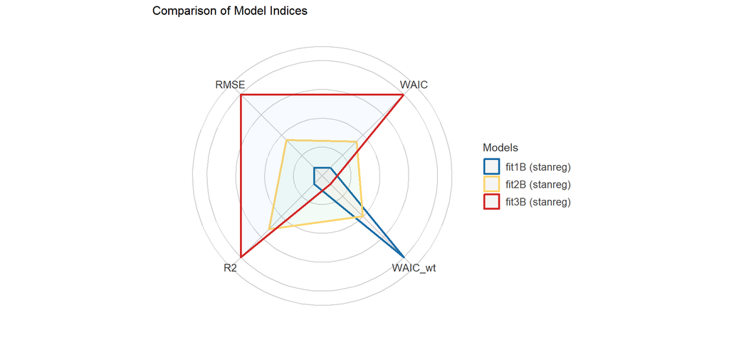

## Why not all the indicators?

```r
plot(compare_performance(fit1B, fit2B, fit3B))
```

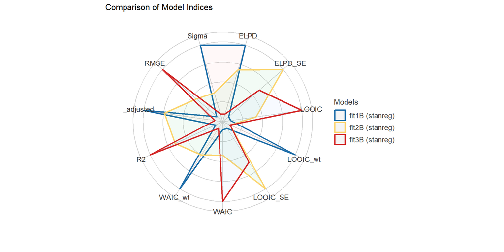

## Checking Bayesian `fit1B`

```r
check_model(fit1B, detrend = FALSE)
```

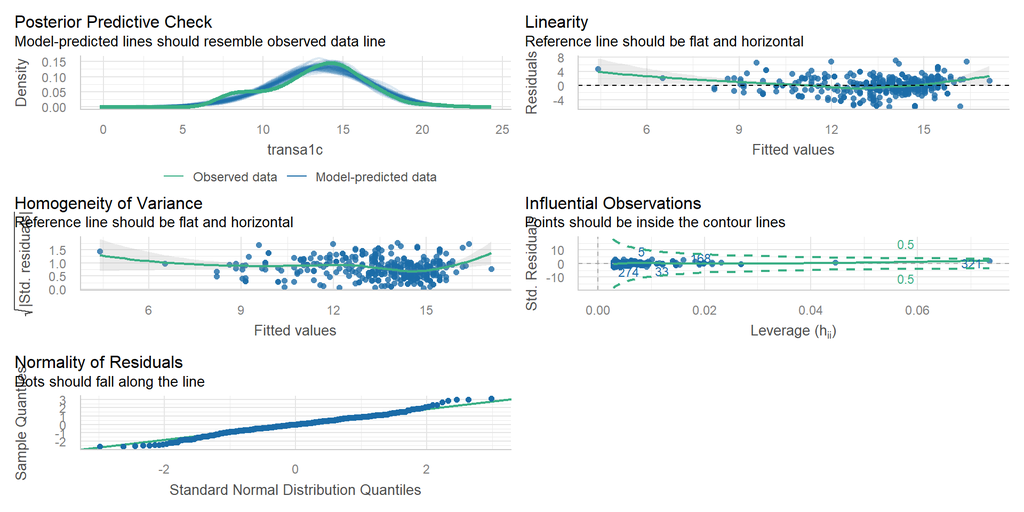

## Checking Bayesian `fit2B`

```r
check_model(fit2B, detrend = FALSE)
```

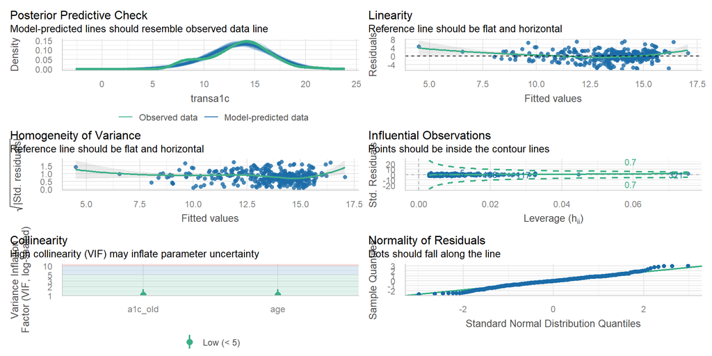

## Checking Bayesian `fit3B`

```r
check_model(fit3B, detrend = FALSE)
```

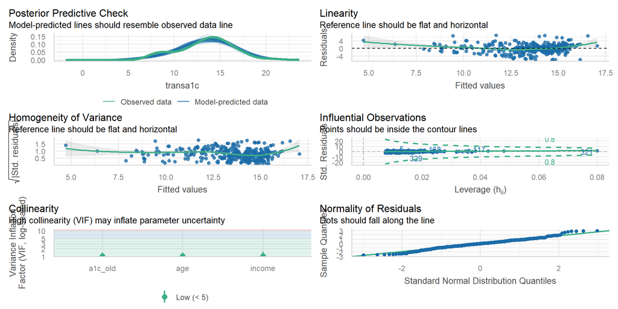

## No `augment` from Bayes fits

The `augment()` function from **broom** doesn’t work with Bayesian fits using `rstanarm()`.

We still want to get our predicted (fitted) values and residuals for each observation in our training sample.

```r
aug_1B <- dm500_i_train |>
  mutate(.fitted = predict(fit1B),
         .resid = transa1c - predict(fit1B))
aug_2B <- dm500_i_train |>
  mutate(.fitted = predict(fit2B),
         .resid = transa1c - predict(fit2B))
aug_3B <- dm500_i_train |>
  mutate(.fitted = predict(fit3B),
         .resid = transa1c - predict(fit3B))
```

## `fit2` model (OLS vs Bayes)

```r
aug2 |> select(1:8) |> head(3)
```

```
# A tibble: 3 × 8
    a1c a1c_old   age income    subject transa1c .fitted .resid
  <dbl>   <dbl> <dbl> <fct>     <chr>      <dbl>   <dbl>  <dbl>
1  12.7     9.2    54 Below_30K S-252       7.87    11.9 -3.99
2   8       8      62 Below_30K S-069      12.5     13.2 -0.725
3   6.5     5.6    55 Below_30K S-275      15.4     15.6 -0.229
```

```r
aug_2B |> head(3)
```

```
# A tibble: 3 × 8
    a1c a1c_old   age income    subject transa1c .fitted .resid
  <dbl>   <dbl> <dbl> <fct>     <chr>      <dbl>   <dbl>  <dbl>
1  12.7     9.2    54 Below_30K S-252       7.87    11.9 -3.99
2   8       8      62 Below_30K S-069      12.5     13.2 -0.723
3   6.5     5.6    55 Below_30K S-275      15.4     15.6 -0.227
```

## Bayes fit to test sample?

Everything is the same as OLS, except we’d have to work around the use of augment in our test data, but `predict()` can handle what we need, as below.

```r
test_1B <- dm500_i_test |>
  mutate(a1c_pred = predict(fit1B, newdata = dm500_i_test),
         a1c_error = transa1c - a1c_pred,
         mod = "fit1B")
test_1B |> head(4) |> gt()
```

| a1c | a1c_old | age | income | subject | transa1c | a1c_pred | a1c_error | mod |
| --- | --- | --- | --- | --- | --- | --- | --- | --- |
| 6.3 | 11.4 | 62 | Higher_than_50K | S-001 | 15.873016 | 9.561669 | 6.31134667 | fit1B |
| 6.5 | 5.8 | 53 | Below_30K | S-004 | 15.384615 | 15.442260 | -0.05764483 | fit1B |
| 5.8 | 6.5 | 48 | Below_30K | S-006 | 17.241379 | 14.707186 | 2.53419297 | fit1B |
| 16.7 | 14.6 | 54 | Below_30K | S-011 | 5.988024 | 6.201331 | -0.21330754 | fit1B |

## Bayes fit to test sample?

```r
test_2B <- dm500_i_test |>
  mutate(a1c_pred = predict(fit2B, newdata = dm500_i_test),
         a1c_error = transa1c - a1c_pred,
         mod = "fit2B")

test_3B <- dm500_i_test |>
  mutate(a1c_pred = predict(fit3B, newdata = dm500_i_test),
         a1c_error = transa1c - a1c_pred,
         mod = "fit3B")
```

## Combine test sample results

- For our Bayesian models…

```r
temp12B <- bind_rows(test_1B, test_2B)
test_resB <- bind_rows(temp12B, test_3B) |>
  relocate(subject, mod, a1c, everything()) |>
  arrange(subject, mod)

testB_summary <- test_resB |>
  group_by(mod) |>
  summarize(MAPE = mean(abs(a1c_error)),
            Max_APE = max(abs(a1c_error)),
            RMSE = sqrt(mean(a1c_error^2)),
            R2_val = cor(a1c, a1c_pred)^2)
```

## Test-Sample Predictions

- From our Bayes models

```r
testB_summary |> gt() |> fmt_number(decimals = 4) |>
  tab_options(table.font.size = 24)
```

| mod | MAPE | Max_APE | RMSE | R2_val |
| --- | --- | --- | --- | --- |
| fit1B | 1.6510 | 8.1551 | 2.1900 | 0.4464 |
| fit2B | 1.6407 | 8.0454 | 2.1743 | 0.4525 |
| fit3B | 1.6504 | 8.2237 | 2.1877 | 0.4539 |

- What’s the winner among these?

## What’s next?

- Do most of this again, including some additional bells and whistles, and some new data.
- Multiple imputation with Bayesian linear models is a topic for 432 (or later.)